# Introduction

This document was produced automatically at 2015-10-05 22:48:45.

## Introduction

The results of the National Propensity to Cycle Tool (NPCT) scenarios are based on a model. This document presents information about the input data, model diagnostics, run time and the key outputs for each region. The aim is to inform users of the NPCT's interactive map how the results were generated. This document assumes some technical knowledge in the area of transport planning.

The code underlying the NPCT is open source, under the conditions of the MIT License. Both the pct and pct-shiny and be modified by others provided attribution to the original.

## Initial parameters

The preset values used to select the study area and filter the origin destination data are described in this section.

```r
# Set local authority and ttwa zone names
la # name of the local authority
```

```
## [1] "Barking-and-Dagenham"
```

```r
la_path <- file.path("pct-data", la)
if(!dir.exists(la_path)) dir.create(la_path) # create data directory

# Minimum flow between od pairs, subsetting lines. High means fewer lines.
mflow <- 80
mdist <- 15 # maximum euclidean distance (km) for subsetting lines
min_zones <- 60 # minumum number of zones in study area before buffer used
buff_dist <- 3 # buffer (km) used to select additional zones (often redundant)
```

## Input zone data

The input zones area are summarised in this section.

The selected region was Barking-and-Dagenham.

The characteristics of zones are as follows:

- Number of zones: 22, compared with 6791 in England
- Median area of zones: 136.4 ha, compared with 300 ha across England

## Input flow data

There are **484** OD pairs with origins and destinations in the study area. Of these, **30** meet the criteria that 80 people reported travelling between these two areas in the 2011 Census (a modifiable parameter used to reduce the computational requirements of the model). That is **6.2%** of OD pairs, accounting for **24.9%** of commutes in the study area.

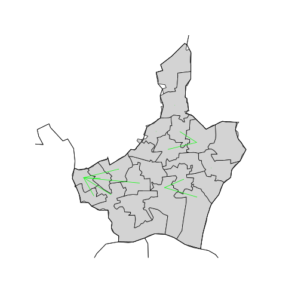

## Hilliness of OD pairs

The average hilliness of zones in the study area is 0.7 degrees, compared with the national average of 2.2. This data is displayed in the figure below.

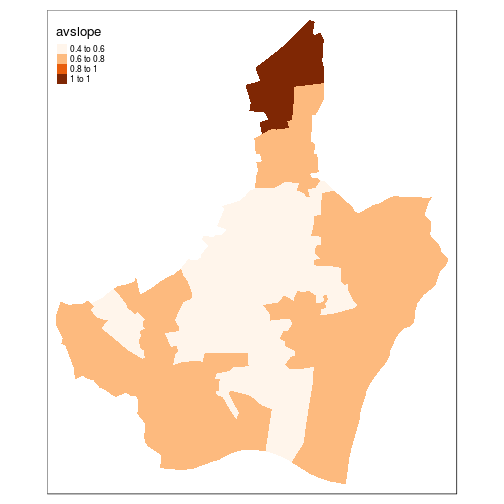

## Lines allocated to the road network

We use CycleStreets.net to estimate optimal routes. An illustration of these routes is presented below.

[output not shown]

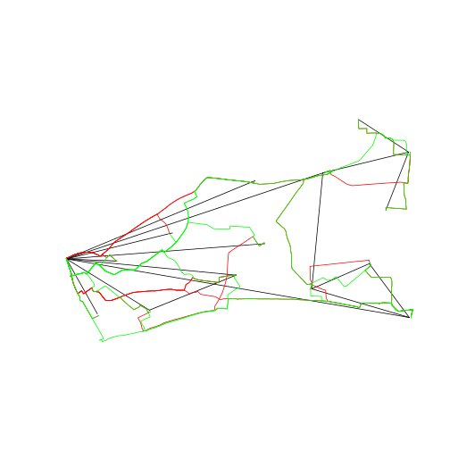

```
## [1] "Warning, lines and routes are different lengths"
```

## Distance distributions

The distance distribution of trips in the study area is displayed in the figure below, which compares the result with the distribution of trips nationwide.

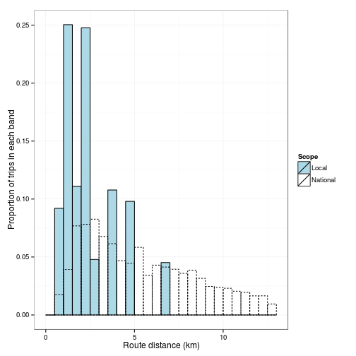

From the nationwide sample of trips, 51.5% of trips are less than 5km.

In the case study area 95.5% of sampled trips are less than 5km.

Subsetting by distance (set to 15 km) and removing inter-zone OD pairs further reduces the number of OD pairs from 30 to 17.

## The flow model

To estimate the potential rate of cycling under different scenarios regression models operating at the flow level are used. These can be seen in the model script which is available [online](https://github.com/npct/pct/blob/master/models/aggregate-model.R).

## Cycling in the study area

The overall rate of cycling in the OD pairs in the study area (after subsetting for distance) is 3.5%, compared a rate from the national data (of equally short OD pairs) of 5.0%.

## Scenarios

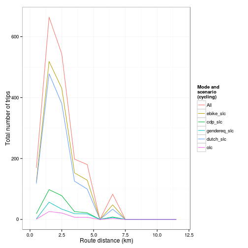

The table below illustrates the same information by distance band.

| dist_band | All | olc | ebike_slc | cdp_slc | gendereq_slc | dutch_slc |
| --- | --- | --- | --- | --- | --- | --- |
| (0,2] | 45.3 | 3.2 | 77.2 | 14 | 7 | 71.5 |
| (2,5] | 50.1 | 3.8 | 77.3 | 13.6 | 7.7 | 65.7 |
| (5,10] | 4.5 | 3.6 | 57.9 | 9.7 | 7.9 | 40.4 |
| Total | 100.0 | 3.5 | 76.3 | 13.6 | 7.4 | 67.2 |

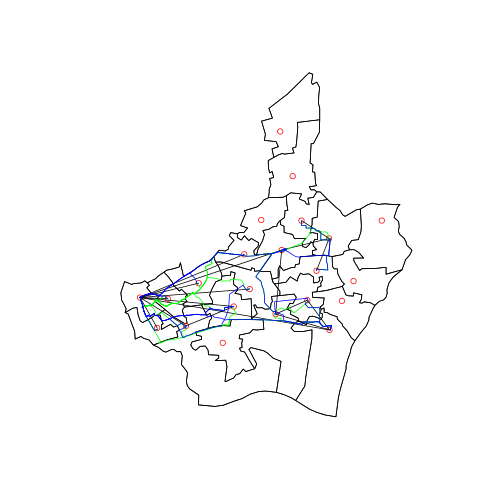

## Flow model results

To estimate the potential rate of cycling under different scenarios regression models operating at the flow level are used. These can be seen in the model script which is available [online](https://github.com/npct/pct/blob/master/models/aggregate-model.R).

[figure not shown]

The correlation between fitted and observed cycling in the model is 0.4, compared with 0.39 nationally.

The values for the coefficients are presented in the table below.

| Model | Alpha | Distance | Dist<sup>0.5</sup> | Hills | Dist/Hills |
| --- | --- | --- | --- | --- | --- |
| National | -2.152 | -0.332 | 0.692 | -0.724 | 0.065 |
| Local | 0.074 | -2.846 | 4.14 | -10.113 | 2.455 |

## Network analysis

Now we aggregate the overlapping routes to create a route network.  
The value of each segment in the network corresponds to the total number of cyclists who we estimate to use the segment.

```
## [1] TRUE
```

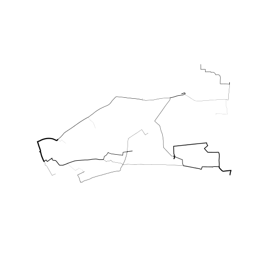

## Time taken

The time taken to run the analysis for this area is presented below.

```r
end_time <- Sys.time()

end_time - start_time
```

```
## Time difference of 29.65143 secs
```